# A6

Khusanbek Mukhammad Azim

11/03/2021

# Question 1

## (a)

The data file is organized into a table where 15 rats from each treatment are grouped together under their bone density. This creates a table with a column for treatment and each treatment row has 3 rows of bone densities.

## (b)

```r
my_url <- "http://ritsokiguess.site/STAC32/isoflavones.txt"
rat <- read_table(my_url)
rat
```

```
## # A tibble: 9 x 2
##   treatment   bone_mineral_density
##   <chr>       <chr>
## 1 "control"   228 207 234 220 217 228
## 2 ""          209 221 204 220 203 219
## 3 ""          218 245 210
## 4 "low_dose"  211 220 211 233 219 233
## 5 ""          226 228 216 225 200 208
## 6 ""          198 208 203
## 7 "high_dose" 250 237 217 206 247 228
## 8 ""          245 232 267 261 221 219
## 9 ""          232 209 255
```

First change the column name of “bone_mineral_density” to just “density” to not write a lot.

```r
rat %>% rename(density=bone_mineral_density) -> rat2
rat2
```

```
## # A tibble: 9 x 2
##   treatment   density
##   <chr>       <chr>
## 1 "control"   228 207 234 220 217 228
## 2 ""          209 221 204 220 203 219
## 3 ""          218 245 210
## 4 "low_dose"  211 220 211 233 219 233
## 5 ""          226 228 216 225 200 208
## 6 ""          198 208 203
## 7 "high_dose" 250 237 217 206 247 228
## 8 ""          245 232 267 261 221 219
## 9 ""          232 209 255
```

Using na_if (https://www.rdocumentation.org/packages/dplyr/versions/0.7.8/topics/na_if) to fill in the blank spots in treatment with NA. Then fill the NA with the previous heading. (https://tidyr.tidyverse.org/reference/fill.html) We also remove “treatment” column as that is no longer needed.

```r
rat2 %>% mutate(t=na_if(treatment, "")) %>%
  select(-treatment) %>%
  select(everything()) %>%
  fill(t) -> rat2
rat2
```

```
## # A tibble: 9 x 2
##   density                 t
##   <chr>                   <chr>
## 1 228 207 234 220 217 228 control
## 2 209 221 204 220 203 219 control
## 3 218 245 210             control
## 4 211 220 211 233 219 233 low_dose
## 5 226 228 216 225 200 208 low_dose
## 6 198 208 203             low_dose
## 7 250 237 217 206 247 228 high_dose
## 8 245 232 267 261 221 219 high_dose
## 9 232 209 255             high_dose
```

Next, using separate_rows we can rearrange the density so that each values is on its own row with the appropriate treatment and is the correct variable type. (https://tidyr.tidyverse.org/reference/separate_rows.html) We can then rename “t” column to “treatment” to be able to recall what the column contains.

```r
rat2 %>% separate_rows(density, sep= ' ', convert = TRUE) %>%
  rename(treatment=t) -> rat2
rat2
```

```
## # A tibble: 45 x 2
##    density treatment
##      <int> <chr>
##  1     228 control
##  2     207 control
##  3     234 control
##  4     220 control
##  5     217 control
##  6     228 control
##  7     209 control
##  8     221 control
##  9     204 control
## 10     220 control
## # ... with 35 more rows
```

Now we have a data frame with 45 rows (15*3=45 patients) and 2 columns of bone densities and treatment.

## (c)

Since we have a categorical and a quantitative variable a side-by-side boxplot is appropriate.

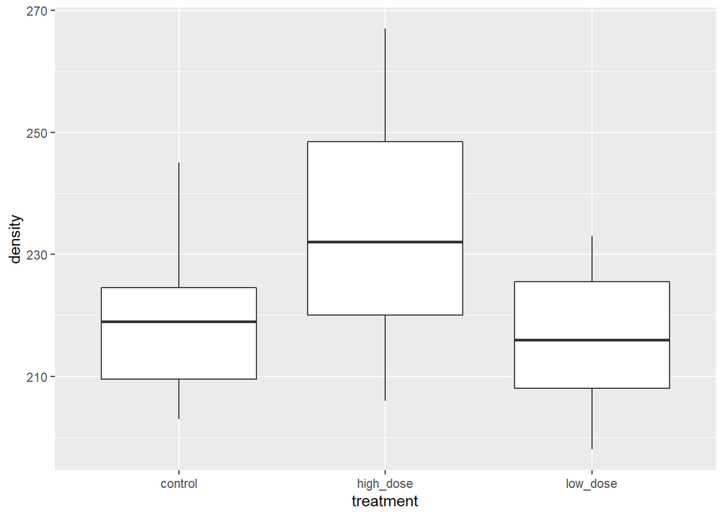

```r
ggplot(rat2, aes(x=treatment, y=density)) + geom_boxplot()
```

## (d)

The boxplots all appear to be symmetric with no outliers.

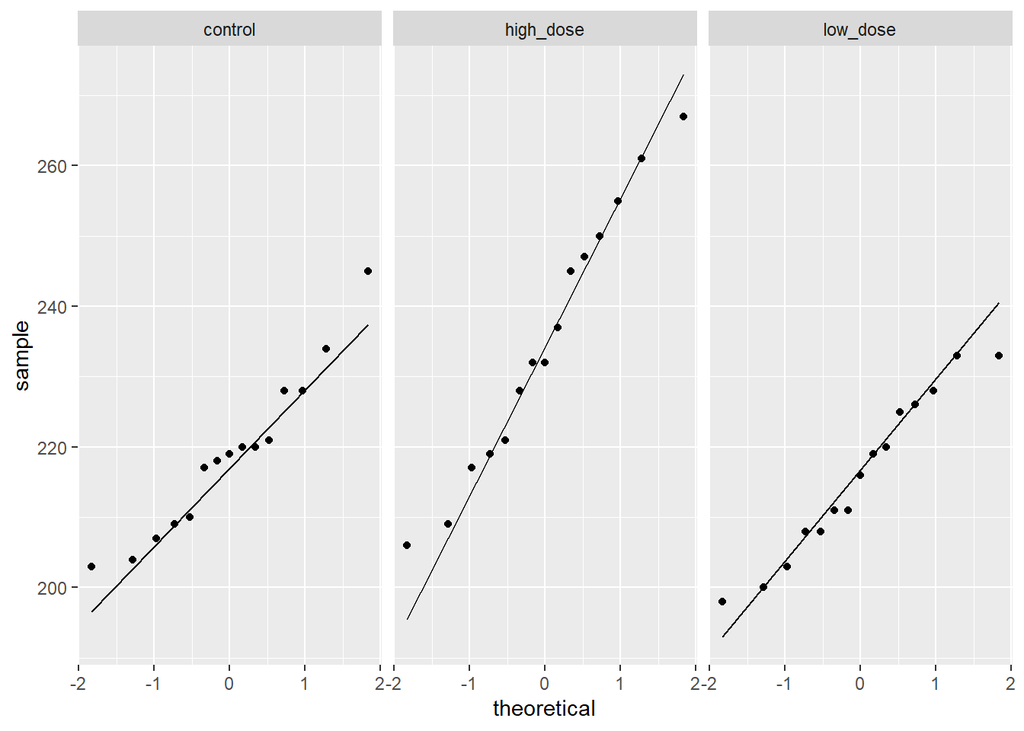

```r
ggplot(rat2, aes(sample=density)) + stat_qq() + stat_qq_line() + facet_wrap(~treatment)
```

From the QQ plots for each treatment we see that each treatment is approximately normally distributed.

Although for the control group, a single low value appears to be slightly too high. Since it is only a single value out of 15, it is not a great concern.